# Исследование объявлений о продаже квартир в Санкт-Петербурге и области

### Предобработка данных

**Привидение наименования столбцов в "змеиный" формат**

```python
# Наведение "красоты" путем переименования столбцов
df.rename(columns={'cityCenters_nearest':'city_centers_nearest', 'parks_around3000':'parks_around_3000','ponds_around3000':'ponds_around_3000'}, inplace=True)
df.columns
```

```
Index(['total_images', 'last_price', 'total_area', 'first_day_exposition',
       'rooms', 'ceiling_height', 'floors_total', 'living_area', 'floor',
       'is_apartment', 'studio', 'open_plan', 'kitchen_area', 'balcony',
       'locality_name', 'airports_nearest', 'city_centers_nearest',
       'parks_around_3000', 'parks_nearest', 'ponds_around_3000',
       'ponds_nearest', 'days_exposition'],
      dtype='object')
```

**Устранение пропусков**

```python
#замена всех значений Nane на 0 и изменение типа столбца "is_apartment" на булево
df['is_apartment'] = df['is_apartment'].fillna(0).astype(bool)
```

```python
#замена всех значений Nane на 0 и изменение типа столбца "is_apartment" на целочисленное
df['balcony'] = df['balcony'].fillna(0).astype(int)
```

```python
#замена всех значений Nane на 0 и изменение типа столбца "ponds_around3000" на целочисленное
df['ponds_around_3000'] = df['ponds_around_3000'].fillna(0).astype(int)
```

```python
#замена всех значений Nane на 0 и изменение типа столбца "airports_nearest" на целочисленное
df['airports_nearest'] = df['airports_nearest'].fillna(0).astype(int)
```

```python
#замена всех значений Nane на 0 и изменение типа столбца "parks_around3000" на целочисленное
df['parks_around_3000'] = df['parks_around_3000'].fillna(0).astype(int)
```

```python
#замена всех значений Nane на 0 и изменение типа столбца "parks_nearest" на целочисленное
df['parks_nearest'] = df['parks_nearest'].fillna(0).astype(int)
```

```python
#замена всех значений Nane на 0 и изменение типа столбца "ponds_nearest" на целочисленное
df['ponds_nearest'] = df['ponds_nearest'].fillna(0).astype(int)
```

```python
#замена всех значений Nane на 0 и изменение типа столбца "cityCenters_nearest" на целочисленное
df['city_centers_nearest'] = df['city_centers_nearest'].fillna(0).astype(int)
```

```python
for loc_name in df['locality_name'].unique():
    median = df.loc[df['locality_name'] == loc_name, 'ceiling_height'].median()
    df.loc[(df['ceiling_height'].isna()) & (df['locality_name'] == loc_name), 'ceiling_height'] = median


#заменим оставщиеся пропуски медианой
df.loc[df['ceiling_height'].isna(), 'ceiling_height'] = df['ceiling_height'].median()
```

```python
#замена всех значенеий Nane на 0 столбца kitchen_area
df['kitchen_area'] = df['kitchen_area'].fillna(0)
df = df.dropna(subset=['floors_total', 'locality_name'])
```

```python
#изменение типа столбца о количесвте этиажей на целочисленное
df['floors_total'] = df['floors_total'].astype(int)
```

```python
print(df.isna().sum())
print(df.info())
df.head(15)
```

```
total_images               0
last_price                 0
total_area                 0
first_day_exposition       0
rooms                      0
ceiling_height             0
floors_total               0
living_area             1865
floor                      0
is_apartment               0
studio                     0
open_plan                  0
kitchen_area               0
balcony                    0
locality_name              0
airports_nearest           0
city_centers_nearest       0
parks_around_3000          0
parks_nearest              0
ponds_around_3000          0
ponds_nearest              0
days_exposition         3171
dtype: int64
<class 'pandas.core.frame.DataFrame'>
Int64Index: 23565 entries, 0 to 23698
Data columns (total 22 columns):
 #   Column                Non-Null Count  Dtype
---  ------                --------------  -----
 0   total_images          23565 non-null  int64
 1   last_price            23565 non-null  float64
 2   total_area            23565 non-null  float64
 3   first_day_exposition  23565 non-null  object
 4   rooms                 23565 non-null  int64
 5   ceiling_height        23565 non-null  float64
 6   floors_total          23565 non-null  int64
 7   living_area           21700 non-null  float64
 8   floor                 23565 non-null  int64
 9   is_apartment          23565 non-null  bool
 10  studio                23565 non-null  bool
 11  open_plan             23565 non-null  bool
 12  kitchen_area          23565 non-null  float64
 13  balcony               23565 non-null  int64
 14  locality_name         23565 non-null  object
 15  airports_nearest      23565 non-null  int64
 16  city_centers_nearest  23565 non-null  int64
 17  parks_around_3000     23565 non-null  int64
 18  parks_nearest         23565 non-null  int64
 19  ponds_around_3000     23565 non-null  int64
 20  ponds_nearest         23565 non-null  int64
 21  days_exposition       20394 non-null  float64
dtypes: bool(3), float64(6), int64(11), object(2)
memory usage: 3.7+ MB
None
```

|  | total_images | last_price | total_area | first_day_exposition | rooms | ceiling_height | floors_total | living_area | floor | is_apartment | studio | open_plan | kitchen_area | balcony | locality_name | airports_nearest | city_centers_nearest | parks_around_3000 | parks_nearest | ponds_around_3000 | ponds_nearest | days_exposition |
| --- | --- | --- | --- | --- | --- | --- | --- | --- | --- | --- | --- | --- | --- | --- | --- | --- | --- | --- | --- | --- | --- | --- |
| 0 | 20 | 13000000.0 | 108.00 | 2019-03-07T00:00:00 | 3 | 2.70 | 16 | 51.00 | 8 | False | False | False | 25.00 | 0 | Санкт-Петербург | 18863 | 16028 | 1 | 482 | 2 | 755 | NaN |
| 1 | 7 | 3350000.0 | 40.40 | 2018-12-04T00:00:00 | 1 | 2.63 | 11 | 18.60 | 1 | False | False | False | 11.00 | 2 | посёлок Шушары | 12817 | 18603 | 0 | 0 | 0 | 0 | 81.0 |
| 2 | 10 | 5196000.0 | 56.00 | 2015-08-20T00:00:00 | 2 | 2.70 | 5 | 34.30 | 4 | False | False | False | 8.30 | 0 | Санкт-Петербург | 21741 | 13933 | 1 | 90 | 2 | 574 | 558.0 |
| 3 | 0 | 64900000.0 | 159.00 | 2015-07-24T00:00:00 | 3 | 2.70 | 14 | NaN | 9 | False | False | False | 0.00 | 0 | Санкт-Петербург | 28098 | 6800 | 2 | 84 | 3 | 234 | 424.0 |
| 4 | 2 | 10000000.0 | 100.00 | 2018-06-19T00:00:00 | 2 | 3.03 | 14 | 32.00 | 13 | False | False | False | 41.00 | 0 | Санкт-Петербург | 31856 | 8098 | 2 | 112 | 1 | 48 | 121.0 |
| 5 | 10 | 2890000.0 | 30.40 | 2018-09-10T00:00:00 | 1 | 2.60 | 12 | 14.40 | 5 | False | False | False | 9.10 | 0 | городской посёлок Янино-1 | 0 | 0 | 0 | 0 | 0 | 0 | 55.0 |
| 6 | 6 | 3700000.0 | 37.30 | 2017-11-02T00:00:00 | 1 | 2.64 | 26 | 10.60 | 6 | False | False | False | 14.40 | 1 | посёлок Парголово | 52996 | 19143 | 0 | 0 | 0 | 0 | 155.0 |
| 7 | 5 | 7915000.0 | 71.60 | 2019-04-18T00:00:00 | 2 | 2.70 | 24 | NaN | 22 | False | False | False | 18.90 | 2 | Санкт-Петербург | 23982 | 11634 | 0 | 0 | 0 | 0 | NaN |
| 8 | 20 | 2900000.0 | 33.16 | 2018-05-23T00:00:00 | 1 | 2.70 | 27 | 15.43 | 26 | False | False | False | 8.81 | 0 | посёлок Мурино | 0 | 0 | 0 | 0 | 0 | 0 | 189.0 |
| 9 | 18 | 5400000.0 | 61.00 | 2017-02-26T00:00:00 | 3 | 2.50 | 9 | 43.60 | 7 | False | False | False | 6.50 | 2 | Санкт-Петербург | 50898 | 15008 | 0 | 0 | 0 | 0 | 289.0 |
| 10 | 5 | 5050000.0 | 39.60 | 2017-11-16T00:00:00 | 1 | 2.67 | 12 | 20.30 | 3 | False | False | False | 8.50 | 0 | Санкт-Петербург | 38357 | 13878 | 1 | 310 | 2 | 553 | 137.0 |
| 11 | 9 | 3300000.0 | 44.00 | 2018-08-27T00:00:00 | 2 | 2.55 | 5 | 31.00 | 4 | False | False | False | 6.00 | 1 | Ломоносов | 48252 | 51677 | 0 | 0 | 0 | 0 | 7.0 |
| 12 | 10 | 3890000.0 | 54.00 | 2016-06-30T00:00:00 | 2 | 2.60 | 5 | 30.00 | 5 | False | False | False | 9.00 | 0 | Сертолово | 0 | 0 | 0 | 0 | 0 | 0 | 90.0 |
| 13 | 20 | 3550000.0 | 42.80 | 2017-07-01T00:00:00 | 2 | 2.56 | 5 | 27.00 | 5 | False | False | False | 5.20 | 1 | Петергоф | 37868 | 33058 | 1 | 294 | 3 | 298 | 366.0 |
| 14 | 1 | 4400000.0 | 36.00 | 2016-06-23T00:00:00 | 1 | 2.60 | 6 | 17.00 | 1 | False | False | False | 8.00 | 0 | Пушкин | 20782 | 30759 | 0 | 0 | 1 | 96 | 203.0 |

**Краткий вывод:** В ходе просмотра массива данных было определено, что всего в массиве 23 699 объекта. Пустые значения были по информации о высоте потолка (9 195), всего этажей в доме (86), жилой площади (1 903), типе жилья, а именно апартаменты это или нет (20 924), площади кухни (2 278), наличии балконов (11 519), наименовании населенного пункта (49), информации о расстоянии да ближайшего аэропорта (5542), расстоянии до центра города (5519), расстоянии до ближайшего парка (15 620), о наличии парка в радиусе 3 км (5 518), о наличии водоемов в радиусе 3 км (5 518), о расстоянии до ближайшего водоема (14 589), о количестве дней размещения объявления (3 171).

Для устранения пропусков было принято решение:  
1) Заменить пропущенную информацию на 0 для информации о наличии балконов, о расстоянии до ближайшего водоема, о наличии водоемов в радиусе 3 км, о наличии парка в радиусе 3 км, расстоянии до ближайшего парка, расстоянии до центра города, информации о расстоянии да ближайшего аэропорта, так как скорее всего данные не были указаны по причине отсутствия вышеописанных объектов (например в квартире нет балконов, в поселке нет парка или водоема). Всем данным был присвоен целочисленный тип.  
2) Пропуски информации о типе квартире также были заменены на 0, так как скорее всего были заполнены данные, если квартира является апартаментами. Для таких данных был присвоен булевый тип.  
3) Скорее всего пропущенная информация о размере кухни отсутствует по причине того, что квартира является студией, прощенные значения были заменены на 0.  
4) Прокушенная информация о высоте потолка была заменена на медианное значение относительно района расположения квартиры. Все что, не получилось заполнить, было заменено на медиану по общим данным, так как высота потолка, как правило, в домах стандартная.  
5) Пропущенная информация о количестве этажей в доме и наименовании населенного пункта была удалена, так как является трудно верифицируемой и количество такой информации достаточно мало.  
6) Пробущенную информацию по столбцам жилая площадь и количество дней со дня публикации была оставлена, т.к. в части количества дней с даты размещения информация отстстсвует по причине активности объявления. Жилую площадь заполнять каким-либо медиааным или срденим значением не совсем корректно, пустых данных по данному столбцу около 10%, поэтому удалять также не верно. Было приянто оставить такие пропуски.

**Устранение неявных дубликатов**

Ранее уже было определено, что явных дубликатов в массиве данных нет. Проверим данные на неявные дубликаты.

```python
#анализ размера уникальных значений по столбцу "населенный пункт"
print('Количество уникальных населенных пунктов:', len(df['locality_name'].unique()))
```

```
Количество уникальных населенных пунктов: 364
```

```python
#для удобства отсортируем значения
sorted(df['locality_name'].unique())
```

```
['Бокситогорск',
 'Волосово',
 'Волхов',
 'Всеволожск',
 'Выборг',
 'Высоцк',
 'Гатчина',
 'Зеленогорск',
 'Ивангород',
 'Каменногорск',
 'Кингисепп',
 'Кириши',
 'Кировск',
 'Колпино',
 'Коммунар',
 'Красное Село',
 'Кронштадт',
 'Кудрово',
 'Лодейное Поле',
 'Ломоносов',
 'Луга',
 'Любань',
 'Мурино',
 'Никольское',
 'Новая Ладога',
 'Отрадное',
 'Павловск',
 'Петергоф',
 'Пикалёво',
 'Подпорожье',
 'Приморск',
 'Приозерск',
 'Пушкин',
 'Санкт-Петербург',
 'Светогорск',
 'Сертолово',
 'Сестрорецк',
 'Сланцы',
 'Сосновый Бор',
 'Сясьстрой',
```

[output cut: 309 more lines]

```
 'посёлок станции Свирь',
 'садоводческое некоммерческое товарищество Лесная Поляна',
 'садовое товарищество Новая Ропша',
 'садовое товарищество Приладожский',
 'садовое товарищество Рахья',
 'садовое товарищество Садко',
 'село Копорье',
 'село Никольское',
 'село Павлово',
 'село Паша',
 'село Путилово',
 'село Рождествено',
 'село Русско-Высоцкое',
 'село Старая Ладога',
 'село Шум']
```

```python
df['locality_name'] = df['locality_name'].str.replace('посёлок', '')
df['locality_name'] = df['locality_name'].str.replace('поселок', '')
df['locality_name'] = df['locality_name'].str.replace('деревня', '')
df['locality_name'] = df['locality_name'].str.replace('городского типа', '')
df['locality_name'] = df['locality_name'].str.replace('при железнодорожной станции', '')
df['locality_name'] = df['locality_name'].str.replace('станции', '')
df['locality_name'] = df['locality_name'].str.replace('городской', '')
df['locality_name'] = df['locality_name'].str.replace('коттеджный ', '')
df['locality_name'] = df['locality_name'].str.replace('садоводческое некоммерческое товарищество', '')
df['locality_name'] = df['locality_name'].str.replace('садовое товарищество', '')
df['locality_name'] = df['locality_name'].str.replace('село', '')
df['locality_name'] = df['locality_name'].str.replace('имени', '')
df['locality_name'] = df['locality_name'].str.lstrip()
print('Количество уникальных населенных пунктов после обработки:',len(df['locality_name'].unique()))
```

```
Количество уникальных населенных пунктов после обработки: 305
```

**Краткий вывод:** Для устранения неявных дубликатов по столбцу "населенный пункт" было принято решение оставить только наименование населенных пунктов. Был применен метод replace. Также для удаления лишних пробелов в начале строки был применен метод lstrip. После проведения всех операций уникальных значений столо 305.

**Устранение аномалий**

Жилая площадь квартиры

```python
df['living_area'].agg(['min','max','mean','median'])
```

```
min         2.000000
max       409.700000
mean       34.454822
median     30.000000
Name: living_area, dtype: float64
```

```python
print('Количество квартир с площадью менее 10 кв.м. -', len(df.query('living_area < 10')))
```

```
Количество квартир с площадью менее 10 кв.м. - 25
```

```python
df.loc[df['living_area'] < 10, 'living_area'] = None
df.query('living_area < 10')
```

|  | total_images | last_price | total_area | first_day_exposition | rooms | ceiling_height | floors_total | living_area | floor | is_apartment | studio | open_plan | kitchen_area | balcony | locality_name | airports_nearest | city_centers_nearest | parks_around_3000 | parks_nearest | ponds_around_3000 | ponds_nearest | days_exposition |
| --- | --- | --- | --- | --- | --- | --- | --- | --- | --- | --- | --- | --- | --- | --- | --- | --- | --- | --- | --- | --- | --- | --- |

Высота потолка

```python
df['ceiling_height'].agg(['min','max','mean','median'])
```

```
min         1.000000
max       100.000000
mean        2.733882
median      2.700000
Name: ceiling_height, dtype: float64
```

```python
sorted(df['ceiling_height'].unique())
```

```
[1.0,
 1.2,
 1.75,
 2.0,
 2.2,
 2.25,
 2.3,
 2.34,
 2.4,
 2.45,
 2.46,
 2.47,
 2.48,
 2.49,
 2.5,
 2.51,
 2.5149999999999997,
 2.52,
 2.525,
 2.53,
 2.54,
 2.55,
 2.5549999999999997,
 2.5599999999999996,
 2.56,
 2.57,
 2.575,
 2.58,
 2.59,
 2.5999999999999996,
 2.6,
 2.61,
 2.615,
 2.62,
 2.625,
 2.63,
 2.64,
 2.65,
 2.6500000000000004,
 2.66,
```

[output cut: 140 more lines]

```
 6.0,
 8.0,
 8.3,
 10.3,
 13.85,
 14.0,
 20.0,
 22.6,
 24.0,
 25.0,
 26.0,
 27.0,
 27.5,
 32.0,
 100.0]
```

```python
df.loc[df['ceiling_height'] >=24, 'ceiling_height'] /= 10
df = df.query('ceiling_height > 2 and ceiling_height < 10')
sorted(df['ceiling_height'].unique())
```

```
[2.2,
 2.25,
 2.3,
 2.34,
 2.4,
 2.45,
 2.46,
 2.47,
 2.48,
 2.49,
 2.5,
 2.51,
 2.5149999999999997,
 2.52,
 2.525,
 2.53,
 2.54,
 2.55,
 2.5549999999999997,
 2.5599999999999996,
 2.56,
 2.57,
 2.575,
 2.58,
 2.59,
 2.5999999999999996,
 2.6,
 2.61,
 2.615,
 2.62,
 2.625,
 2.63,
 2.64,
 2.65,
 2.6500000000000004,
 2.66,
 2.67,
 2.675,
 2.68,
 2.69,
```

[output cut: 124 more lines]

```
 4.45,
 4.5,
 4.65,
 4.7,
 4.8,
 4.9,
 5.0,
 5.2,
 5.3,
 5.5,
 5.6,
 5.8,
 6.0,
 8.0,
 8.3]
```

**Вывод по предобработке данных:** При проведении предобработки данных было обнаружено большое число пропущенных значений (по некоторым данным пропуски достигали 20 000). Для устранения пропусков были применены методы удаления строк (если таких значений не много), замены на 0 (там где это логически возможно и можно объяснить причину пропуска), замены на медианные значения по общим параметрам и похожим свойствам (по принадлежности к району). Пропуски, которые не возможно заменить, были оставлены. Также были привидены в соответствия типы столбцов, были отработаны аномалии (путем правок или удаления). Был произведен поиск явных дубликатов - в массиве таких не оказалось. Произведена подмена неявных дубликатов (было принято решение оставить только наименование населенных пунктов). В результате предобработки данных массив сократился с 23 699 до 23 546 тыс. данных, что составляет менее 1% от исходных размеров.

### Добавление столбцов с данными

**Подсчет цены одного кв. метра**

```python
df['price_sq_metrs'] = (df['last_price'] / df['total_area']).round(2)
df.head()
```

|  | total_images | last_price | total_area | first_day_exposition | rooms | ceiling_height | floors_total | living_area | floor | is_apartment | studio | open_plan | kitchen_area | balcony | locality_name | airports_nearest | city_centers_nearest | parks_around_3000 | parks_nearest | ponds_around_3000 | ponds_nearest | days_exposition | price_sq_metrs |
| --- | --- | --- | --- | --- | --- | --- | --- | --- | --- | --- | --- | --- | --- | --- | --- | --- | --- | --- | --- | --- | --- | --- | --- |
| 0 | 20 | 13000000.0 | 108.0 | 2019-03-07T00:00:00 | 3 | 2.70 | 16 | 51.0 | 8 | False | False | False | 25.0 | 0 | Санкт-Петербург | 18863 | 16028 | 1 | 482 | 2 | 755 | NaN | 120370.37 |
| 1 | 7 | 3350000.0 | 40.4 | 2018-12-04T00:00:00 | 1 | 2.63 | 11 | 18.6 | 1 | False | False | False | 11.0 | 2 | Шушары | 12817 | 18603 | 0 | 0 | 0 | 0 | 81.0 | 82920.79 |
| 2 | 10 | 5196000.0 | 56.0 | 2015-08-20T00:00:00 | 2 | 2.70 | 5 | 34.3 | 4 | False | False | False | 8.3 | 0 | Санкт-Петербург | 21741 | 13933 | 1 | 90 | 2 | 574 | 558.0 | 92785.71 |
| 3 | 0 | 64900000.0 | 159.0 | 2015-07-24T00:00:00 | 3 | 2.70 | 14 | NaN | 9 | False | False | False | 0.0 | 0 | Санкт-Петербург | 28098 | 6800 | 2 | 84 | 3 | 234 | 424.0 | 408176.10 |
| 4 | 2 | 10000000.0 | 100.0 | 2018-06-19T00:00:00 | 2 | 3.03 | 14 | 32.0 | 13 | False | False | False | 41.0 | 0 | Санкт-Петербург | 31856 | 8098 | 2 | 112 | 1 | 48 | 121.0 | 100000.00 |

```python
df['price_sq_metrs'].agg(['min','max','mean','median']).round(2)
```

```
min           111.83
max       1907500.00
mean        99408.43
median      95000.00
Name: price_sq_metrs, dtype: float64
```

**Краткий вывод:** При анализе цены за квадратный метр видно, что средняя цена по Лениградской области составляет порядка 100 т.р. Выбивается минимальное значение в стоимости квадратного метра. Такое значение необходимо убрать. Предположим, что минимальная цена начинается от 10 тыс. руб.

```python
df = df.query('price_sq_metrs > 10000')
df['price_sq_metrs'].min()
```

```
10185.19
```

**Форматирование даты**

```python
df['first_day_exposition'] = pd.to_datetime(df['first_day_exposition'], format='%Y-%m-%dT%')
df['weekday_exposition'] = df['first_day_exposition'].dt.weekday
df['monht_exposition'] = df['first_day_exposition'].dt.month
df['year_exposition'] = df['first_day_exposition'].dt.year
df.head()
```

|  | total_images | last_price | total_area | first_day_exposition | rooms | ceiling_height | floors_total | living_area | floor | is_apartment | studio | open_plan | kitchen_area | balcony | locality_name | airports_nearest | city_centers_nearest | parks_around_3000 | parks_nearest | ponds_around_3000 | ponds_nearest | days_exposition | price_sq_metrs | weekday_exposition | monht_exposition | year_exposition |
| --- | --- | --- | --- | --- | --- | --- | --- | --- | --- | --- | --- | --- | --- | --- | --- | --- | --- | --- | --- | --- | --- | --- | --- | --- | --- | --- |
| 0 | 20 | 13000000.0 | 108.0 | 2019-03-07 | 3 | 2.70 | 16 | 51.0 | 8 | False | False | False | 25.0 | 0 | Санкт-Петербург | 18863 | 16028 | 1 | 482 | 2 | 755 | NaN | 120370.37 | 3 | 3 | 2019 |
| 1 | 7 | 3350000.0 | 40.4 | 2018-12-04 | 1 | 2.63 | 11 | 18.6 | 1 | False | False | False | 11.0 | 2 | Шушары | 12817 | 18603 | 0 | 0 | 0 | 0 | 81.0 | 82920.79 | 1 | 12 | 2018 |
| 2 | 10 | 5196000.0 | 56.0 | 2015-08-20 | 2 | 2.70 | 5 | 34.3 | 4 | False | False | False | 8.3 | 0 | Санкт-Петербург | 21741 | 13933 | 1 | 90 | 2 | 574 | 558.0 | 92785.71 | 3 | 8 | 2015 |
| 3 | 0 | 64900000.0 | 159.0 | 2015-07-24 | 3 | 2.70 | 14 | NaN | 9 | False | False | False | 0.0 | 0 | Санкт-Петербург | 28098 | 6800 | 2 | 84 | 3 | 234 | 424.0 | 408176.10 | 4 | 7 | 2015 |
| 4 | 2 | 10000000.0 | 100.0 | 2018-06-19 | 2 | 3.03 | 14 | 32.0 | 13 | False | False | False | 41.0 | 0 | Санкт-Петербург | 31856 | 8098 | 2 | 112 | 1 | 48 | 121.0 | 100000.00 | 1 | 6 | 2018 |

Для удобства формат даты был переведен в гггг-мм-дд, данные по времени добавлены не были, т.к. во всех датах стоял 00:00. Также были добавлены столбцы день, месяц и год публикации объявления.

```python
df['year_exposition'].value_counts()
```

```
2018    8473
2017    8154
2019    2868
2016    2743
2015    1166
2014     136
Name: year_exposition, dtype: int64
```

**Добавление информации об этаже**

```python
def categorize_floors(row):

    floor = row ['floor']
    floors_total = row['floors_total']

    if floor == 1:
        return 'первый'
    elif floor == floors_total:
        return 'последний'
    else:
        return 'другой'
```

```python
df['floor_info'] = df.apply(categorize_floors, axis=1)

#проверка работы функции
df['floor_info'].unique()
```

```
array(['другой', 'первый', 'последний'], dtype=object)
```

```python
#подсчет значений по заданным параметрам
df['floor_info'].value_counts()
```

```
другой       17312
последний     3324
первый        2904
Name: floor_info, dtype: int64
```

**Краткий вывод:** Как видно из анализа, особой популярностью пользуются этажи расположенные не на первом и последнем этажах, что вполне логично.

**Добавление информации о расстоянии до центра города**

```python
df['city_centers_nearest_km'] = (df['city_centers_nearest'] / 1000).astype(int)
df[['city_centers_nearest', 'city_centers_nearest_km']].head()
```

|  | city_centers_nearest | city_centers_nearest_km |
| --- | --- | --- |
| 0 | 16028 | 16 |
| 1 | 18603 | 18 |
| 2 | 13933 | 13 |
| 3 | 6800 | 6 |
| 4 | 8098 | 8 |

**Вывод:** Для добавления информации о расстоянии до центра города в км столбец "city_centers_nearest" был разделен на 1000.

### Исследовательский анализ данных

**Анализ общей площади**

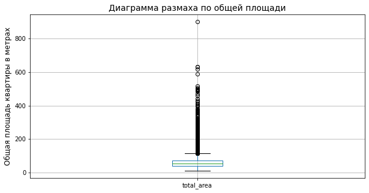

```python
#построение диаграммы размаха
df.boxplot(column=['total_area'], figsize=(10,5), grid=True)
plt.title(f'Диаграмма размаха по общей площади', fontsize = 14)
plt.ylabel('Общая площадь квартиры в метрах', fontsize = 12)
plt.show()
```

```python
#получение статистических данных
df['total_area'].describe().round(2)
```

```
count    23540.00
mean        60.33
std         35.67
min         12.00
25%         40.00
50%         52.00
75%         69.70
max        900.00
Name: total_area, dtype: float64
```

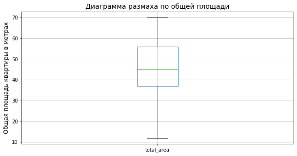

```python
#построение диаграммы размаха и отсечение квартир больше 70 метров
good_df = df.query('total_area < 70')
good_df.boxplot(column=['total_area'], figsize=(10,5), grid=True)
plt.title(f'Диаграмма размаха по общей площади', fontsize = 14)
plt.ylabel('Общая площадь квартиры в метрах', fontsize = 12)
plt.show()
```

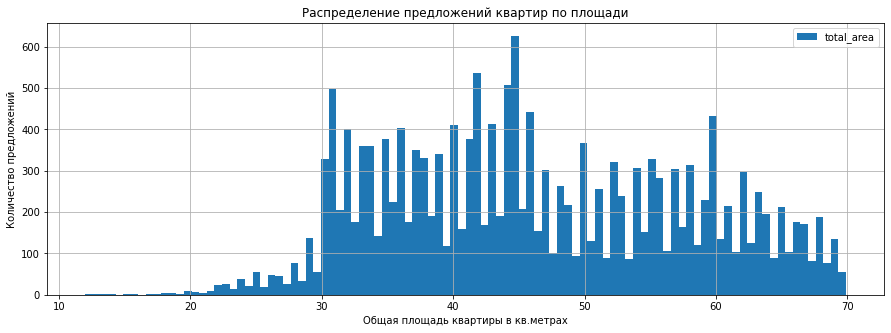

```python
#сортировка и построение гистограммы
good_df.sort_values(by='total_area', ascending=True).plot(kind='hist', y='total_area', bins=100, figsize=(15,5), grid=True)

plt.title('Распределение предложений квартир по площади')
plt.xlabel('Общая площадь квартиры в кв.метрах')
plt.ylabel('Количество предложений')
plt.show()
```

**Краткий вывод:** Согласно построенной гистограмме можно сделать предположить, что наибольшее количество предложений приходится на размер квартиры от 30 до 45 кв. метров. Самое большое количество предложений для квартир с площадью 45 кв.м.

**Анализ жилой площади**

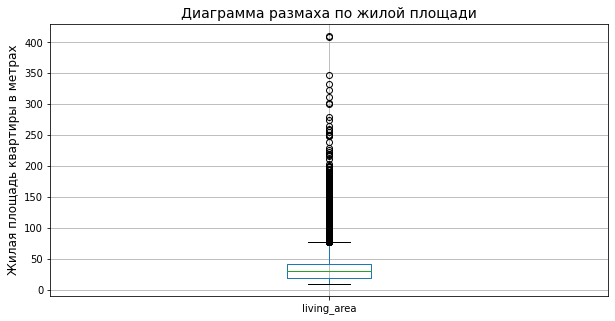

```python
#построение диаграммы размаха
df.boxplot(column=['living_area'], figsize=(10,5), grid=True)
plt.title(f'Диаграмма размаха по жилой площади', fontsize = 14)
plt.ylabel('Жилая площадь квартиры в метрах', fontsize = 12)
plt.show()
```

```python
#получение статистических данных
df['living_area'].describe().round(2)
```

```
count    21653.00
mean        34.49
std         22.04
min         10.00
25%         18.60
50%         30.00
75%         42.30
max        409.70
Name: living_area, dtype: float64
```

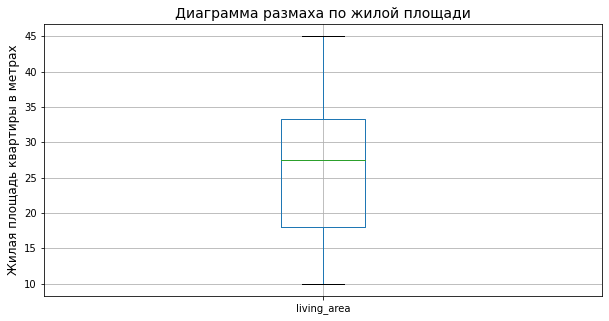

```python
#построение диаграммы размаха и отсечение квартир с жилой площадью более 45 метров
good_df = df.query('living_area < 45')
good_df.boxplot(column=['living_area'], figsize=(10,5), grid=True)
plt.title(f'Диаграмма размаха по жилой площади', fontsize = 14)
plt.ylabel('Жилая площадь квартиры в метрах', fontsize = 12)
plt.show()
```

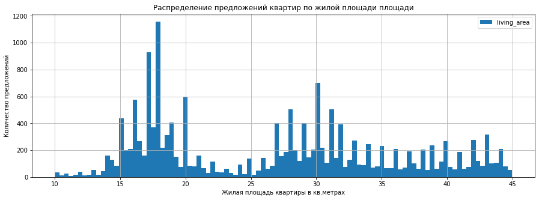

```python
#сортировка и построение гистограммы
good_df.sort_values(by='living_area', ascending=True).plot(kind='hist', y='living_area', bins=100, figsize=(15,5), grid=True)

plt.title('Распределение предложений квартир по жилой площади площади')
plt.xlabel('Жилая площадь квартиры в кв.метрах')
plt.ylabel('Количество предложений')
plt.show()
```

**Краткий вывод:** Согласно построенной гистограмме можно сделать вывод, что имеется два диапазона наиболее популярных предложений по продажам квартир. Больший пик приходится на жилую площадь в диапозоне от 15 до 20 кв. метров. Второй пик приходится на диапазон от 27 до 33 кв.м.

**Анализ площади кухни**

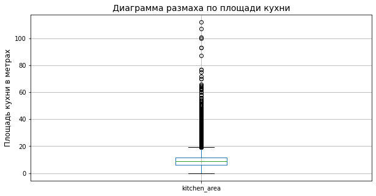

```python
#построение диаграммы размаха
df.boxplot(column=['kitchen_area'], figsize=(10,5), grid=True)
plt.title(f'Диаграмма размаха по площади кухни', fontsize = 14)
plt.ylabel('Площадь кухни в метрах', fontsize = 12)
plt.show()
```

```python
#получение статистических данных
df['kitchen_area'].describe().round(2)
```

```
count    23540.00
mean         9.57
std          6.41
min          0.00
25%          6.30
50%          9.00
75%         11.42
max        112.00
Name: kitchen_area, dtype: float64
```

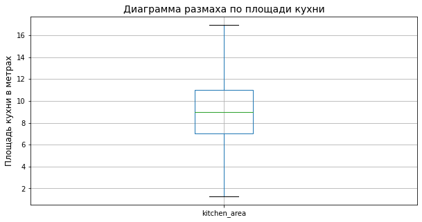

```python
#построение диаграммы размаха и отсечение квартир с площадью кухонь более 11 метров и квартир-студий
good_df = df.query('kitchen_area < 17 & kitchen_area > 0')
good_df.boxplot(column=['kitchen_area'], figsize=(10,5), grid=True)
plt.title(f'Диаграмма размаха по площади кухни', fontsize = 14)
plt.ylabel('Площадь кухни в метрах', fontsize = 12)
plt.show()
```

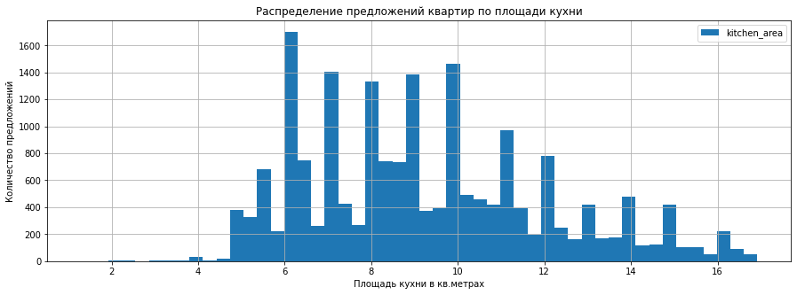

```python
#сортировка и построение гистограммы
good_df.sort_values(by='kitchen_area', ascending=True).plot(kind='hist', y='kitchen_area', bins=50, figsize=(15,5), grid=True)

plt.title('Распределение предложений квартир по площади кухни')
plt.xlabel('Площадь кухни в кв.метрах')
plt.ylabel('Количество предложений')
plt.show()
```

**Краткий вывод:** Самые популярные размеры кухни держаться в диапазоне 6 - 10 кв. метров.

**Анализ цены объекта**

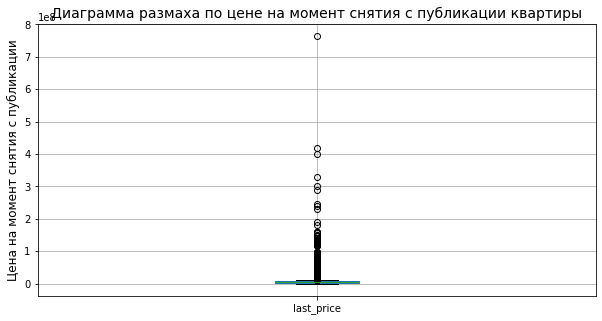

```python
#построение диаграммы размаха
df.boxplot(column=['last_price'], figsize=(10,5), grid=True)
plt.title(f'Диаграмма размаха по цене на момент снятия с публикации квартиры', fontsize = 14)
plt.ylabel('Цена на момент снятия с публикации', fontsize = 12)
plt.show()
```

```python
#получение статистических данных
df['last_price'].describe().round(2)
```

```
count    2.354000e+04
mean     6.543002e+06
std      1.091578e+07
min      4.300000e+05
25%      3.407500e+06
50%      4.650000e+06
75%      6.799000e+06
max      7.630000e+08
Name: last_price, dtype: float64
```

Согласно диаграмме размаха, большинство предложений расположено в диапазоне 1,2 и 7 млн руб. Остальные данные уберем.

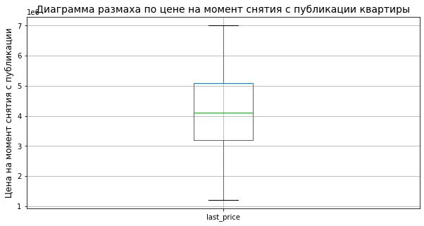

```python
#построение диаграммы размаха и отсечение квартир со стоимстью квартир в диапазоне 1,2-7 млн руб.
good_df = df.query('last_price < 7000000 & last_price > 1200000')
good_df.boxplot(column=['last_price'], figsize=(10,5), grid=True)
plt.title(f'Диаграмма размаха по цене на момент снятия с публикации квартиры', fontsize = 14)
plt.ylabel('Цена на момент снятия с публикации', fontsize = 12)
plt.show()
```

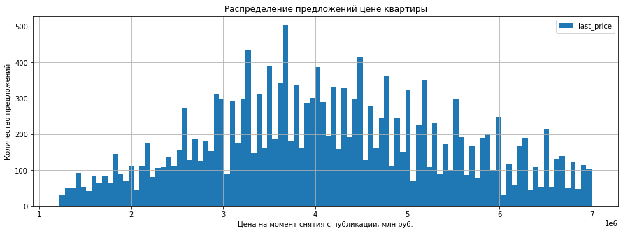

```python
#сортировка и построение гистограммы
good_df.sort_values(by='last_price', ascending=True).plot(kind='hist', y='last_price', bins=100, figsize=(15,5), grid=True)

plt.title('Распределение предложений цене квартиры')
plt.xlabel('Цена на момент снятия с публикации, млн руб.')
plt.ylabel('Количество предложений')
plt.show()
```

**Кратки вывод:** Наибольшее число предложений в диапазоне 3,2-5,2 млн руб. Самый популярные предложения со стоимостью 3,7 млн руб.

**Анализ количества комнат**

```python
#подсчет количества значений по комнатам
df['rooms'].value_counts()
```

```
1     7994
2     7887
3     5774
4     1172
5      325
0      194
6      104
7       59
8       12
9        8
10       3
11       2
14       2
19       1
16       1
12       1
15       1
Name: rooms, dtype: int64
```

При анализе количества квартир по комнатам в них видно, что квартир с количеством комнат более 6 уже достаточно мало. Такие предложения остечем.

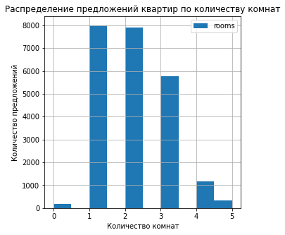

```python
#отсечение данных по количеству комнат и построение столбчатого графика
good_df = df.query('rooms < 6')
good_df.sort_values(by='rooms', ascending=True).plot(kind='hist', y='rooms', bins=10, figsize=(5,5), grid=True)

plt.title('Распределение предложений квартир по количеству комнат')
plt.xlabel('Количество комнат')
plt.ylabel('Количество предложений')
plt.show()
```

**Краткий вывод:** Самым популярным вариантом является одно- и двухкомнатные квартиры.

**Анализ высоты потолков**

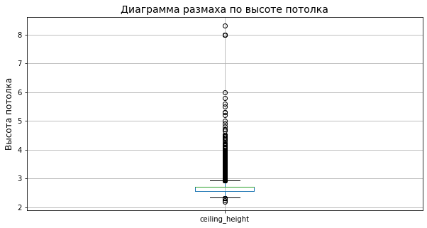

```python
#построение диаграммы размаха
df.boxplot(column=['ceiling_height'], figsize=(10,5), grid=True)
plt.title(f'Диаграмма размаха по высоте потолка', fontsize = 14)
plt.ylabel('Высота потолка', fontsize = 12)
plt.show()
```

```python
#получение статистических данных
df['ceiling_height'].describe().round(2)
```

```
count    23540.00
mean         2.71
std          0.24
min          2.20
25%          2.55
50%          2.70
75%          2.70
max          8.30
Name: ceiling_height, dtype: float64
```

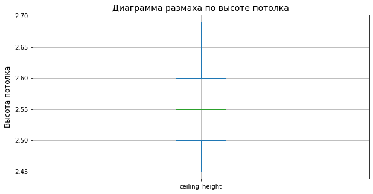

```python
#построение диаграммы размаха и отсечение квартир с высотой потолка ниже 2,4 и выше 2,7
good_df = df.query('ceiling_height < 2.7 & ceiling_height > 2.4')
good_df.boxplot(column=['ceiling_height'], figsize=(10,5), grid=True)
plt.title(f'Диаграмма размаха по высоте потолка', fontsize = 14)
plt.ylabel('Высота потолка', fontsize = 12)
plt.show()
```

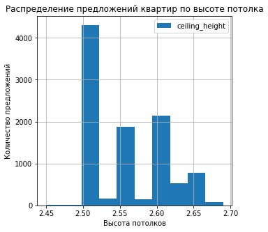

```python
#сортировка и построение гистограммы
good_df.sort_values(by='ceiling_height', ascending=True).plot(kind='hist', y='ceiling_height', bins=10, figsize=(5,5), grid=True)

plt.title('Распределение предложений квартир по высоте потолка')
plt.xlabel('Высота потолков')
plt.ylabel('Количество предложений')
```

**Анализ этажности дома**

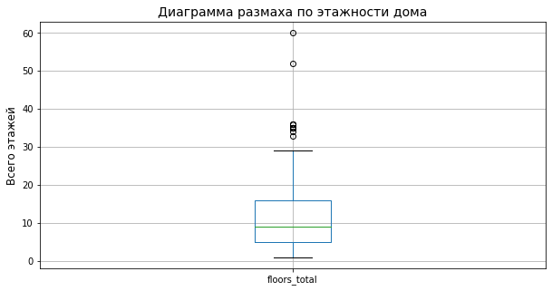

```python
#построение диаграммы размаха
df.boxplot(column=['floors_total'], figsize=(10,5), grid=True)
plt.title(f'Диаграмма размаха по этажности дома', fontsize = 14)
plt.ylabel('Всего этажей', fontsize = 12)
plt.show()
```

В соответствии с диграммой размаха, дома, чья этажность выше 30, выбиваются из выборки.

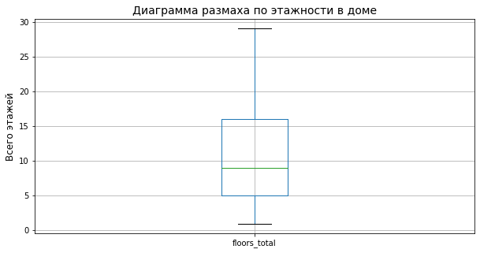

```python
#построение диаграммы размаха и отсечение квартир количеством этажей больше 30
good_df = df.query('floors_total < 30')
good_df.boxplot(column=['floors_total'], figsize=(10,5), grid=True)
plt.title(f'Диаграмма размаха по этажности в доме', fontsize = 14)
plt.ylabel('Всего этажей', fontsize = 12)
plt.show()
```

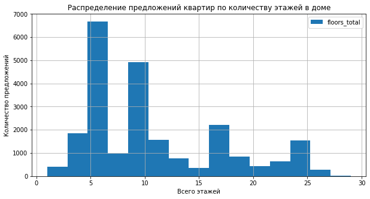

```python
#сортировка и построение гистограммы
good_df.sort_values(by='floors_total', ascending=True).plot(kind='hist', y='floors_total', bins=15, figsize=(10,5), grid=True)

plt.title('Распределение предложений квартир по количеству этажей в доме')
plt.xlabel('Всего этажей')
plt.ylabel('Количество предложений')
plt.show()
```

**Краткий вывод:** Больше всего предложений для домов с 5 и 10 этажами.

**Анализ типа этажа**

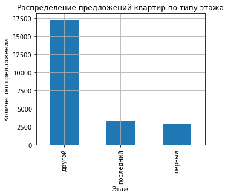

```python
#Сортировка и построения барплота по типу этажа
good_df['floor_info'].value_counts().plot(kind='bar', x='floor_info', figsize=(5,4), grid=True)

plt.title('Распределение предложений квартир по типу этажа')
plt.xlabel('Этаж')
plt.ylabel('Количество предложений')
plt.show()
```

```python
good_df['floor_info'].value_counts()
```

```
другой       17281
последний     3324
первый        2904
Name: floor_info, dtype: int64
```

**Краткий вывод:** Как видно из графика, больше всего предложений на не на первом и не на последнем этажах. Предложениий продаж на последних этажах больше, чем на первых (ок. 15%).

**Анализ этажа квартиры**

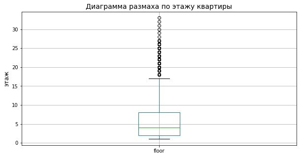

```python
#построение диаграммы размаха
df.boxplot(column=['floor'], figsize=(10,5), grid=True)
plt.title(f'Диаграмма размаха по этажу квартиры', fontsize = 14)
plt.ylabel('этаж', fontsize = 12)
plt.show()
```

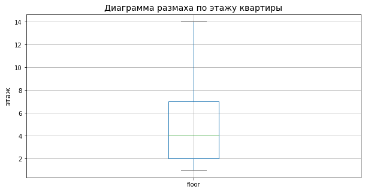

```python
#построение диаграммы размаха и отсечение квартир выше 15 этажа
good_df = df.query('floor < 15')
good_df.boxplot(column=['floor'], figsize=(10,5), grid=True)
plt.title(f'Диаграмма размаха по этажу квартиры', fontsize = 14)
plt.ylabel('этаж', fontsize = 12)
plt.show()
```

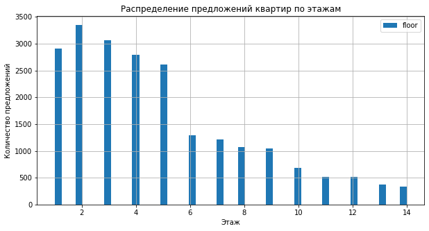

```python
#сортировка и построение гистограммы
good_df.sort_values(by='floor', ascending=True).plot(kind='hist', y='floor', bins=50, figsize=(10,5), grid=True)

plt.title('Распределение предложений квартир по этажам')
plt.xlabel('Этаж')
plt.ylabel('Количество предложений')
plt.show()
```

**Краткий вывод:** Больше всего предложений для квартир на 2 этаже, далее идет 3 этаж. Стоит отметить, что выше этаж, тем предложений меньше.

**Анализ расстояния до центра города в метрах**

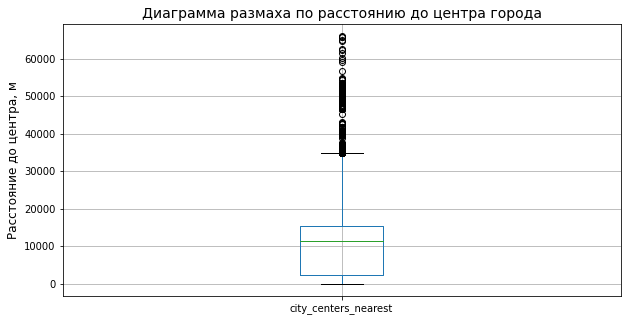

```python
#построение диаграммы размаха
df.boxplot(column=['city_centers_nearest'], figsize=(10,5), grid=True)
plt.title(f'Диаграмма размаха по расстоянию до центра города', fontsize = 14)
plt.ylabel('Расстояние до центра, м', fontsize = 12)
plt.show()
```

```python
#получение статистических данных
df['city_centers_nearest'].describe().round(2)
```

```
count    23540.00
mean     10884.64
std       9639.90
min          0.00
25%       2230.75
50%      11247.00
75%      15245.00
max      65968.00
Name: city_centers_nearest, dtype: float64
```

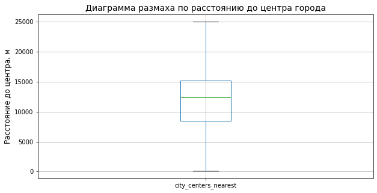

```python
#построение диаграммы размаха и отсечение квартир c удаленностью от центра до 25 км
good_df = df.query('city_centers_nearest < 25000 & city_centers_nearest != 0')
good_df.boxplot(column=['city_centers_nearest'], figsize=(10,5), grid=True)
plt.title(f'Диаграмма размаха по расстоянию до центра города', fontsize = 14)
plt.ylabel('Расстояние до центра, м', fontsize = 12)
plt.show()
```

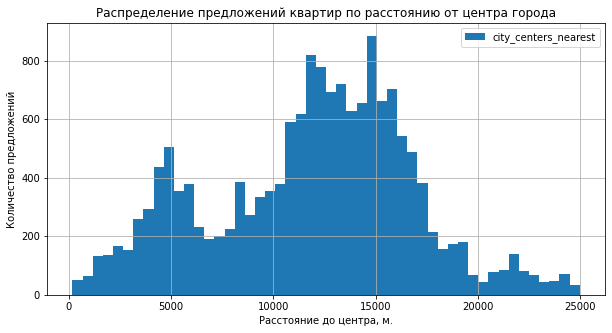

```python
#сортировка и построение гистограммы
good_df.sort_values(by='city_centers_nearest', ascending=True).plot(kind='hist', y='city_centers_nearest', bins=50, figsize=(10,5), grid=True)

plt.title('Распределение предложений квартир по расстоянию от центра города')
plt.xlabel('Расстояние до центра, м.')
plt.ylabel('Количество предложений')
plt.show()
```

**Краткий вывод:** Больше всего предложений для квартир на расстоянии от 10 до 16 км. Также много квартир продается на удаленности ок. 5 км.